# Assignment_01

#### Classifying IMDB Movie Reviews: Binary Classification Neural Network

#### MIS 64061: Advanced Machine Learning

The purpose of this assignment is to explore and extend knowlege of my first Neural Network model.

In this assignment, we will be using the "IMDB dataset", and the goal is to classify movies reviews as positive or negative. This dataset has a set of 50,000 highly-polarized reviews from the Internet Movie Database. They are split into 25,000 reviews for training and 25,000 reviews for testing, each set consisting in 50% negative and 50% positive reviews.

### **Import the Keras library and IMDB dataset**

```python
from numpy.random import seed
seed(123)
from tensorflow.keras.datasets import imdb

(train_data, train_labels), (test_data, test_labels) = imdb.load_data(
    num_words=10000)
```

Note that **"num_words=10000"** is added in the code. It means that only the top 10,000 most common words will be used to have a more manageable size vector data.

The **train_data** and **test_data** are lists of reviews, each review being a list of word indices (encoding a sequence of words). The train_labels and test_labels are lists of 0s and 1s, where 0 stands for "negative" and 1 stands for "positive."

**Training Dataset**

```python
train_labels[0]
```

```
1
```

```python
len(train_labels)
```

```
25000
```

```python
max([max(sequence) for sequence in train_data])
```

```
9999
```

```python
train_data
```

```
array([list([1, 14, 22, 16, 43, 530, 973, 1622, 1385, 65, 458, 4468, 66, 3941, 4, 173, 36, 256, 5, 25, 100, 43, 838, 112, 50, 670, 2, 9, 35, 480, 284, 5, 150, 4, 172, 112, 167, 2, 336, 385, 39, 4, 172, 4536, 1111, 17, 546, 38, 13, 447, 4, 192, 50, 16, 6, 147, 2025, 19, 14, 22, 4, 1920, 4613, 469, 4,…
       list([1, 194, 1153, 194, 8255, 78, 228, 5, 6, 1463, 4369, 5012, 134, 26, 4, 715, 8, 118, 1634, 14, 394, 20, 13, 119, 954, 189, 102, 5, 207, 110, 3103, 21, 14, 69, 188, 8, 30, 23, 7, 4, 249, 126, 93, 4, 114, 9, 2300, 1523, 5, 647, 4, 116, 9, 35, 8163, 4, 229, 9, 340, 1322, 4, 118, 9, 4, 130, 4…
       list([1, 14, 47, 8, 30, 31, 7, 4, 249, 108, 7, 4, 5974, 54, 61, 369, 13, 71, 149, 14, 22, 112, 4, 2401, 311, 12, 16, 3711, 33, 75, 43, 1829, 296, 4, 86, 320, 35, 534, 19, 263, 4821, 1301, 4, 1873, 33, 89, 78, 12, 66, 16, 4, 360, 7, 4, 58, 316, 334, 11, 4, 1716, 43, 645, 662, 8, 257, 85, 1200,…
       ...,
       list([1, 11, 6, 230, 245, 6401, 9, 6, 1225, 446, 2, 45, 2174, 84, 8322, 4007, 21, 4, 912, 84, 2, 325, 725, 134, 2, 1715, 84, 5, 36, 28, 57, 1099, 21, 8, 140, 8, 703, 5, 2, 84, 56, 18, 1644, 14, 9, 31, 7, 4, 9406, 1209, 2295, 2, 1008, 18, 6, 20, 207, 110, 563, 12, 8, 2901, 2, 8, 97, 6, 20, 53,…
       list([1, 1446, 7079, 69, 72, 3305, 13, 610, 930, 8, 12, 582, 23, 5, 16, 484, 685, 54, 349, 11, 4120, 2959, 45, 58, 1466, 13, 197, 12, 16, 43, 23, 2, 5, 62, 30, 145, 402, 11, 4131, 51, 575, 32, 61, 369, 71, 66, 770, 12, 1054, 75, 100, 2198, 8, 4, 105, 37, 69, 147, 712, 75, 3543, 44, 257, 390, …
       list([1, 17, 6, 194, 337, 7, 4, 204, 22, 45, 254, 8, 106, 14, 123, 4, 2, 270, 2, 5, 2, 2, 732, 2098, 101, 405, 39, 14, 1034, 4, 1310, 9, 115, 50, 305, 12, 47, 4, 168, 5, 235, 7, 38, 111, 699, 102, 7, 4, 4039, 9245, 9, 24, 6, 78, 1099, 17, 2345, 2, 21, 27, 9685, 6139, 5, 2, 1603, 92, 1183, 4, …
      dtype=object)
```

**Test Dataset**

```python
test_labels[0]
```

```
0
```

```python
len(test_labels)
```

```
25000
```

```python
test_data
```

```
array([list([1, 591, 202, 14, 31, 6, 717, 10, 10, 2, 2, 5, 4, 360, 7, 4, 177, 5760, 394, 354, 4, 123, 9, 1035, 1035, 1035, 10, 10, 13, 92, 124, 89, 488, 7944, 100, 28, 1668, 14, 31, 23, 27, 7479, 29, 220, 468, 8, 124, 14, 286, 170, 8, 157, 46, 5, 27, 239, 16, 179, 2, 38, 32, 25, 7944, 451, 202, 14, …
       list([1, 14, 22, 3443, 6, 176, 7, 5063, 88, 12, 2679, 23, 1310, 5, 109, 943, 4, 114, 9, 55, 606, 5, 111, 7, 4, 139, 193, 273, 23, 4, 172, 270, 11, 7216, 2, 4, 8463, 2801, 109, 1603, 21, 4, 22, 3861, 8, 6, 1193, 1330, 10, 10, 4, 105, 987, 35, 841, 2, 19, 861, 1074, 5, 1987, 2, 45, 55, 221, 15,…
       list([1, 111, 748, 4368, 1133, 2, 2, 4, 87, 1551, 1262, 7, 31, 318, 9459, 7, 4, 498, 5076, 748, 63, 29, 5161, 220, 686, 2, 5, 17, 12, 575, 220, 2507, 17, 6, 185, 132, 2, 16, 53, 928, 11, 2, 74, 4, 438, 21, 27, 2, 589, 8, 22, 107, 2, 2, 997, 1638, 8, 35, 2076, 9019, 11, 22, 231, 54, 29, 1706, …
       ...,
       list([1, 13, 1408, 15, 8, 135, 14, 9, 35, 32, 46, 394, 20, 62, 30, 5093, 21, 45, 184, 78, 4, 1492, 910, 769, 2290, 2515, 395, 4257, 5, 1454, 11, 119, 2, 89, 1036, 4, 116, 218, 78, 21, 407, 100, 30, 128, 262, 15, 7, 185, 2280, 284, 1842, 2, 37, 315, 4, 226, 20, 272, 2942, 40, 29, 152, 60, 181,…
       list([1, 11, 119, 241, 9, 4, 840, 20, 12, 468, 15, 94, 3684, 562, 791, 39, 4, 86, 107, 8, 97, 14, 31, 33, 4, 2960, 7, 743, 46, 1028, 9, 3531, 5, 4, 768, 47, 8, 79, 90, 145, 164, 162, 50, 6, 501, 119, 7, 9, 4, 78, 232, 15, 16, 224, 11, 4, 333, 20, 4, 985, 200, 5, 2, 5, 9, 1861, 8, 79, 357, 4, …
       list([1, 6, 52, 7465, 430, 22, 9, 220, 2594, 8, 28, 2, 519, 3227, 6, 769, 15, 47, 6, 3482, 4067, 8, 114, 5, 33, 222, 31, 55, 184, 704, 5586, 2, 19, 346, 3153, 5, 6, 364, 350, 4, 184, 5586, 9, 133, 1810, 11, 5417, 2, 21, 4, 7298, 2, 570, 50, 2005, 2643, 9, 6, 1249, 17, 6, 2, 2, 21, 17, 6, 1211…
      dtype=object)
```

**Decoding reviews back to text**

Here, in this section we can see that integers can be decoded to reviews(Words)

```python
word_index = imdb.get_word_index()
reverse_word_index = dict(
    [(value, key) for (key, value) in word_index.items()])
decoded_review = " ".join(
    [reverse_word_index.get(i - 3, "?") for i in train_data[0]])
```

```python
decoded_review
```

```
"? this film was just brilliant casting location scenery story direction everyone's really suited the part they played and you could just imagine being there robert ? is an amazing actor and now the same being director ? father came from the same scottish island as myself so i loved the fact there w…
```

**Data Preparation**

We have to change our reviews from characters into tensors. There are two ways we could do that:

- We could pad our lists so that they all have the same length, and turn them into an integer tensor of shape (samples, word_indices), then use as first layer in our network a layer capable of handling such integer tensors.
- We could one-hot-encode our lists to turn them into vectors of 0s and 1s. Concretely, this would mean for instance turning the sequence [3, 5] into a 10,000-dimensional vector that would be all-zeros except for indices 3 and 5, which would be ones. Then we could use as first layer in our network a Dense layer, capable of handling floating point vector data.
- We will do the second option manually.

```python
import numpy as np
def vectorize_sequences(sequences, dimension=10000):
    results = np.zeros((len(sequences), dimension))
    for i, sequence in enumerate(sequences):
        for j in sequence:
            results[i, j] = 1.
    return results

# Data Vectorization
x_train = vectorize_sequences(train_data)
x_test = vectorize_sequences(test_data)
```

```python
x_train[0]
```

```
array([0., 1., 1., ..., 0., 0., 0.])
```

```python
x_test[0]
```

```
array([0., 1., 1., ..., 0., 0., 0.])
```

```python
# Label vectorization
```

```python
y_train = np.asarray(train_labels).astype("float32")
y_test = np.asarray(test_labels).astype("float32")
```

### **Build the Neural Network 2 Hidden Layers**

**Model Architecture**

Our input data are now vectors in a 2D tensor of shape (samples, 10000). Our output is a scalar, either 0 or 1. A stack of fully connected layers (layes.dense) with relu activation functions for the hidden layers do well with these type of problems.

```python
from tensorflow import keras
from tensorflow.keras import layers
seed(123)
model2 = keras.Sequential([
    layers.Dense(16, activation="relu"),
    layers.Dense(16, activation="relu"),
    layers.Dense(1, activation="sigmoid")
])
```

**Model Compilation**

In this section of model compilation,the below three parameters plays a significant role.

- Loss function: takes the predictions of the network and the true targets and computes a distance score
- Optimizer: The loss score used as a feedback signal to adjust value of weights in order to lower the loss score, the adjustment is done by optimizer
- Metrics: to evaluate the performance during training and testing.

```python
model2.compile(optimizer="rmsprop",
              loss="binary_crossentropy",
              metrics=["accuracy"])
```

**Validating the approach**

In order to validate the performance of the training set, we have to create a validation set.

```python
seed(123)
x_val = x_train[:10000]
partial_x_train = x_train[10000:]
y_val = y_train[:10000]
partial_y_train = y_train[10000:]
```

**Model Training**

Now we will train our model for 20 epochs with batch size of 512 samples and also we will record loss and accuracy.

```python
seed(123)
history2 = model2.fit(partial_x_train,
                    partial_y_train,
                    epochs=20,
                    batch_size=512,
                    validation_data=(x_val, y_val))
```

**OBSERVATIONS:**

The loss and accuracy on the training were 0.0028 and 99% respectively. Regarding the loss and accuracy on the validation set were 0.68 and 86.5%.

Now, let's see the History object, which is a dictionary containing data about everything that happened during training.

```python
history_dict = history2.history
history_dict.keys()
```

```
dict_keys(['loss', 'accuracy', 'val_loss', 'val_accuracy'])
```

**Plotting the Training and Validation loss**

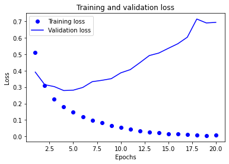

```python
import matplotlib.pyplot as plt

twoly_binary_accuracy = history2.history['accuracy']
twoly_val_binary_accuracy = history2.history['val_accuracy']
twoly_loss = history2.history['loss']
twoly_val_loss = history2.history['val_loss']

twoly_epochs = range(1, len(twoly_binary_accuracy) + 1)

# "bo" is for "blue dot"
plt.plot(twoly_epochs, twoly_loss, 'bo', label='Training loss')
# b is for "solid blue line"
plt.plot(twoly_epochs, twoly_val_loss, 'b', label='Validation loss')
plt.title('Training and validation loss')
plt.xlabel('Epochs')
plt.ylabel('Loss')
plt.legend()

plt.show()
```

**Plotting the Training and Validation accuracy**

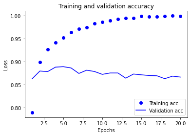

```python
plt.clf()   # clear figure
twoly_acc_values = history_dict['accuracy']
twoly_val_acc_values = history_dict['val_accuracy']

plt.plot(twoly_epochs, twoly_acc_values, 'bo', label='Training acc')
plt.plot(twoly_epochs, twoly_val_acc_values, 'b', label='Validation acc')
plt.title('Training and validation accuracy')
plt.xlabel('Epochs')
plt.ylabel('Loss')
plt.legend()

plt.show()
```

**Observations:** From the above graph, it is evident that the validation loss tends to increase after the 4th epoch, which implies that we are overfitting the model.

Now, let's build the model again from scratch, then evaluate it on the test set.

**Retraining a model from scratch**

```python
np.random.seed(123)
model2 = keras.Sequential([
    layers.Dense(16, activation="relu"),
    layers.Dense(16, activation="relu"),
    layers.Dense(1, activation="sigmoid")
])
model2.compile(optimizer="rmsprop",
              loss="binary_crossentropy",
              metrics=["accuracy"])
model2.fit(x_train, y_train, epochs=4, batch_size=512)
results2 = model2.evaluate(x_test, y_test)
```

```python
results2
```

```
[0.2903200089931488, 0.8843600153923035]
```

**Model Prediction on New dataset**

```python
model2.predict(x_test)
```

```
array([[0.21300727],
       [0.99958026],
       [0.8962792 ],
       ...,
       [0.1477308 ],
       [0.07443413],
       [0.65575993]], dtype=float32)
```

### **Build the Neural Network 1 Hidden Layers**

Let's build our NN with one layer, and everything will keep the same as the previous 2-Layer NN.

```python
seed(123)
model1 = keras.Sequential([
    layers.Dense(16, activation="relu"),
    layers.Dense(1, activation="sigmoid")
])

model1.compile(optimizer="rmsprop",
              loss="binary_crossentropy",
              metrics=["accuracy"])

x_val = x_train[:10000]
partial_x_train = x_train[10000:]

y_val = y_train[:10000]
partial_y_train = y_train[10000:]


history1 = model1.fit(partial_x_train,
                    partial_y_train,
                    epochs=20,
                    batch_size=512,
                    validation_data=(x_val, y_val))
```

```python
history_dict = history1.history
history_dict.keys()
```

```
dict_keys(['loss', 'accuracy', 'val_loss', 'val_accuracy'])
```

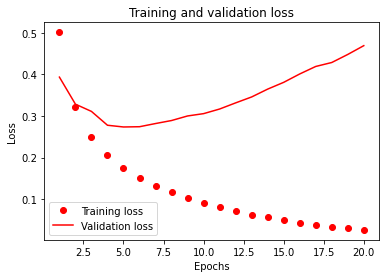

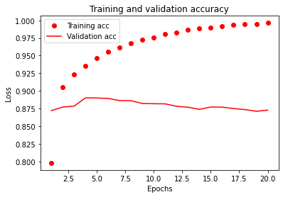

```python
import matplotlib.pyplot as plt

onely_accuracy = history1.history['accuracy']
onely_val_accuracy = history1.history['val_accuracy']
onely_loss = history1.history['loss']
onely_val_loss = history1.history['val_loss']

onely_epochs = range(1, len(onely_accuracy) + 1)


plt.plot(onely_epochs, onely_loss, 'ro', label='Training loss')
plt.plot(onely_epochs, onely_val_loss, 'r', label='Validation loss')
plt.title('Training and validation loss')
plt.xlabel('Epochs')
plt.ylabel('Loss')
plt.legend()

plt.show()

plt.clf()   # clear figure
onely_acc_values = history_dict['accuracy']
onely_val_acc_values = history_dict['val_accuracy']

plt.plot(onely_epochs, onely_acc_values, 'ro', label='Training acc')
plt.plot(onely_epochs, onely_val_acc_values, 'r', label='Validation acc')
plt.title('Training and validation accuracy')
plt.xlabel('Epochs')
plt.ylabel('Loss')
plt.legend()

plt.show()
```

**Model Retraining**

```python
np.random.seed(123)
model1 = keras.Sequential([
    layers.Dense(16, activation="relu"),
    layers.Dense(1, activation="sigmoid")
])

model1.compile(optimizer="rmsprop",
              loss="binary_crossentropy",
              metrics=["accuracy"])
model1.fit(x_train, y_train, epochs=5, batch_size=512)
results1 = model1.evaluate(x_test, y_test)
```

```python
results1
```

```
[0.2963736653327942, 0.8815199732780457]
```

```python
model1.predict(x_test)
```

```
array([[0.176231  ],
       [0.999903  ],
       [0.78139794],
       ...,
       [0.10142779],
       [0.08349872],
       [0.46241453]], dtype=float32)
```

## **Build the Neural Network 3 Hidden Layers**

Let's build our NN with 3 layers, and everything will keep the same as the previous 2-Layer NN.

```python
np.random.seed(123)
model3 = keras.Sequential([
    layers.Dense(16, activation="relu"),
    layers.Dense(16, activation="relu"),
    layers.Dense(16, activation="relu"),
    layers.Dense(1, activation="sigmoid")
])

model3.compile(optimizer='rmsprop',
              loss='binary_crossentropy',
              metrics=['accuracy'])

x_val = x_train[:10000]
partial_x_train = x_train[10000:]

y_val = y_train[:10000]
partial_y_train = y_train[10000:]


original = model3.fit(partial_x_train,
                    partial_y_train,
                    epochs=20,
                    batch_size=512,
                    validation_data=(x_val, y_val))
```

```python
history_dict = original.history
history_dict.keys()
```

```
dict_keys(['loss', 'accuracy', 'val_loss', 'val_accuracy'])
```

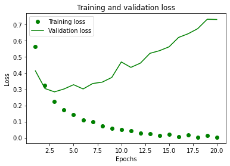

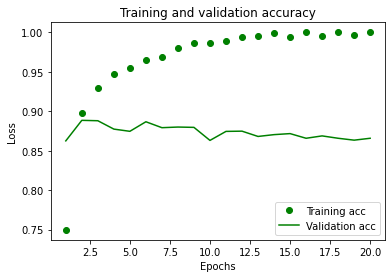

```python
threely_accuracy = original.history['accuracy']
threely_val_accuracy = original.history['val_accuracy']
threely_loss = original.history['loss']
threely_val_loss = original.history['val_loss']

threely_epochs = range(1, len(threely_accuracy) + 1)

# "bo" is for "blue dot"
plt.plot(threely_epochs, threely_loss, 'go', label='Training loss')
# b is for "solid blue line"
plt.plot(threely_epochs, threely_val_loss, 'g', label='Validation loss')
plt.title('Training and validation loss')
plt.xlabel('Epochs')
plt.ylabel('Loss')
plt.legend()

plt.show()

plt.clf()   # clear figure
threely_acc_values = history_dict['accuracy']
threely_val_acc_values = history_dict['val_accuracy']

plt.plot(threely_epochs, threely_acc_values, 'go', label='Training acc')
plt.plot(threely_epochs, threely_val_acc_values, 'g', label='Validation acc')
plt.title('Training and validation accuracy')
plt.xlabel('Epochs')
plt.ylabel('Loss')
plt.legend()

plt.show()
```

```python
np.random.seed(123)
model3 = keras.Sequential([
    layers.Dense(16, activation="relu"),
    layers.Dense(16, activation="relu"),
    layers.Dense(16, activation="relu"),
    layers.Dense(1, activation="sigmoid")
])


model3.compile(optimizer='rmsprop',
              loss='binary_crossentropy',
              metrics=['accuracy'])

model3.fit(x_train, y_train, epochs=3, batch_size=512)
results3 = model3.evaluate(x_test, y_test)
```

```python
results3
```

```
[0.28544944524765015, 0.8864399790763855]
```

```python
model3.predict(x_test)
```

```
array([[0.28482294],
       [0.9943148 ],
       [0.9160887 ],
       ...,
       [0.11432344],
       [0.10776621],
       [0.5965096 ]], dtype=float32)
```

Since the Three Layers model has the better accuracy on test compared to 1 and 2 layers, we will continue the following section using this only model and find the way to improve its accuracy.

## **Neural Network more hidden units or fewer hidden units**

Deciding the number of neurons in the hidden layers is a very important part of deciding your overall neural network architecture. Though these layers do not directly interact with the external environment, they have a tremendous influence on the final output. Both the number of hidden layers and the number of neurons in each of these hidden layers must be carefully considered.

- Using too few neurons in the hidden layers will result in something called underfitting. Underfitting occurs when there are too few neurons in the hidden layers to adequately detect the signals in a complicated data set.
- Using too many neurons in the hidden layers can result in several problems. First, too many neurons in the hidden layers may result in overfitting. Overfitting occurs when the neural network has so much information processing capacity that the limited amount of information contained in the training set is not enough to train all of the neurons in the hidden layers.

**Building Model with 32 Neurons**

```python
# Our vectorized training data
x_train = vectorize_sequences(train_data)
# Our vectorized test data
x_test = vectorize_sequences(test_data)
# Our vectorized labels
y_train = np.asarray(train_labels).astype('float32')
y_test = np.asarray(test_labels).astype('float32')
```

```python
np.random.seed(123)
model32 = keras.Sequential([
    layers.Dense(32, activation="relu"),
    layers.Dense(32, activation="relu"),
    layers.Dense(32, activation="relu"),
    layers.Dense(1, activation="sigmoid")
])

# Model compilation
model32.compile(optimizer='rmsprop',
              loss='binary_crossentropy',
              metrics=['accuracy'])
# validation
x_val = x_train[:10000]
partial_x_train = x_train[10000:]

y_val = y_train[:10000]
partial_y_train = y_train[10000:]

# Model Fit
np.random.seed(123)
history32 = model32.fit(partial_x_train,
                    partial_y_train,
                    epochs=20,
                    batch_size=512,
                    validation_data=(x_val, y_val))
```

```python
history_dict = history32.history
history_dict.keys()
```

```
dict_keys(['loss', 'accuracy', 'val_loss', 'val_accuracy'])
```

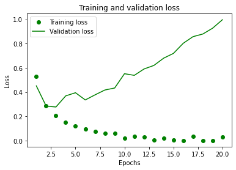

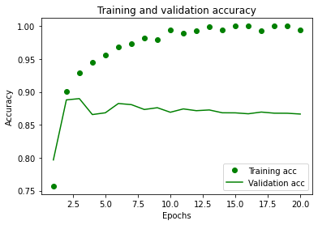

```python
import matplotlib.pyplot as plt

threely_accuracy = history32.history['accuracy']
threely_val_accuracy = history32.history['val_accuracy']
threely_loss = history32.history['loss']
threely_val_loss = history32.history['val_loss']

threely_epochs = range(1, len(threely_accuracy) + 1)

# "bo" is for "blue dot"
plt.plot(threely_epochs, threely_loss, 'go', label='Training loss')
# b is for "solid blue line"
plt.plot(threely_epochs, threely_val_loss, 'g', label='Validation loss')
plt.title('Training and validation loss')
plt.xlabel('Epochs')
plt.ylabel('Loss')
plt.legend()

plt.show()

plt.clf()   # clear figure
threely_acc_values = history_dict['accuracy']
threely_val_acc_values = history_dict['val_accuracy']

plt.plot(threely_epochs, threely_acc_values, 'go', label='Training acc')
plt.plot(threely_epochs, threely_val_acc_values, 'g', label='Validation acc')
plt.title('Training and validation accuracy')
plt.xlabel('Epochs')
plt.ylabel('Accuracy')
plt.legend()

plt.show()
```

```python
np.random.seed(123)
model32 = keras.Sequential([
    layers.Dense(32, activation="relu"),
    layers.Dense(32, activation="relu"),
    layers.Dense(32, activation="relu"),
    layers.Dense(1, activation="sigmoid")
])

model32.compile(optimizer='rmsprop',
              loss='binary_crossentropy',
              metrics=['accuracy'])

history_test = model32.fit(x_train, y_train, epochs=3, batch_size=512)
results32 = model32.evaluate(x_test, y_test)
```

```python
model32.predict(x_test)
```

```
array([[0.08821324],
       [0.99784374],
       [0.20144016],
       ...,
       [0.03813091],
       [0.03197759],
       [0.3626031 ]], dtype=float32)
```

**Model building with 128 Neurons**

```python
np.random.seed(123)
model128 = keras.Sequential([
    layers.Dense(128, activation="relu"),
    layers.Dense(128, activation="relu"),
    layers.Dense(128, activation="relu"),
    layers.Dense(1, activation="sigmoid")
])

# Model compilation
model128.compile(optimizer='rmsprop',
              loss='binary_crossentropy',
              metrics=['accuracy'])
# validation
x_val = x_train[:10000]
partial_x_train = x_train[10000:]

y_val = y_train[:10000]
partial_y_train = y_train[10000:]

# Model Fit
np.random.seed(123)
history = model128.fit(partial_x_train,
                    partial_y_train,
                    epochs=20,
                    batch_size=512,
                    validation_data=(x_val, y_val))
```

```python
np.random.seed(123)
model128 = keras.Sequential([
    layers.Dense(128, activation="relu"),
    layers.Dense(128, activation="relu"),
    layers.Dense(128, activation="relu"),
    layers.Dense(1, activation="sigmoid")
])

model128.compile(optimizer='rmsprop',
              loss='binary_crossentropy',
              metrics=['accuracy'])

history_test = model128.fit(x_train, y_train, epochs=2, batch_size=512)
results128 = model128.evaluate(x_test, y_test)
```

```python
model128.predict(x_test)
```

```
array([[0.11237273],
       [0.99995977],
       [0.99161506],
       ...,
       [0.11777958],
       [0.10880882],
       [0.7446415 ]], dtype=float32)
```

## **Neural Network with MSE Loss Function**

**Binary Cross-Entropy**

Cross-entropy is the default loss function to use for binary classification problems. It is intended for use with binary classification where the target values are in the set {0, 1}. How it works? Cross-entropy will calculate a score that summarizes the average difference between the actual and predicted probability distributions for predicting class 1. The score is minimized and a perfect cross-entropy value is 0.

Cross-entropy can be specified as the loss function in Keras by specifying ‘binary_crossentropy‘ when compiling the model.

**Mean Squared Error Loss**

The Mean Squared Error, or MSE, loss is the default loss to use for regression problems. How it works? Mean squared error is calculated as the average of the squared differences between the predicted and actual values. The result is always positive regardless of the sign of the predicted and actual values and a perfect value is 0.0. The squaring means that larger mistakes result in more error than smaller mistakes, meaning that the model is punished for making larger mistakes.

The mean squared error loss function can be used in Keras by specifying ‘mse‘ or ‘mean_squared_error‘ as the loss function when compiling the model.

Reference: https://machinelearningmastery.com/how-to-choose-loss-functions-when-training-deep-learning-neural-networks/

Let's try to use MSE loss function instead of binary_crossentropy loss function and check results

**Model building using MSE loss function**

```python
# Our vectorized training data
x_train = vectorize_sequences(train_data)
# Our vectorized test data
x_test = vectorize_sequences(test_data)

# Our vectorized labels
y_train = np.asarray(train_labels).astype('float32')
y_test = np.asarray(test_labels).astype('float32')


# Model Network Architecture

np.random.seed(123)
model = keras.Sequential([
    layers.Dense(16, activation="relu"),
    layers.Dense(16, activation="relu"),
    layers.Dense(16, activation="relu"),
    layers.Dense(1, activation="sigmoid")
])

# Model compilation
model.compile(optimizer='rmsprop',
              loss='mean_squared_error',
              metrics=['accuracy'])
# validation
x_val = x_train[:10000]
partial_x_train = x_train[10000:]

y_val = y_train[:10000]
partial_y_train = y_train[10000:]

# Model Fit
np.random.seed(123)
history = model.fit(partial_x_train,
                    partial_y_train,
                    epochs=20,
                    batch_size=512,
                    validation_data=(x_val, y_val))
```

```python
history_dict = history.history
history_dict.keys()
```

```
dict_keys(['loss', 'accuracy', 'val_loss', 'val_accuracy'])
```

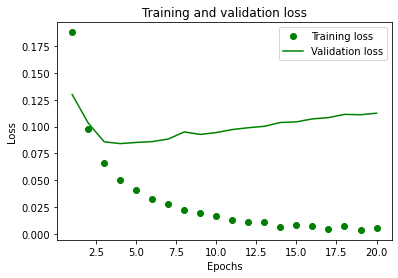

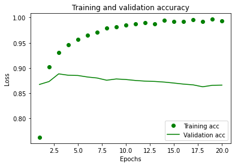

```python
import matplotlib.pyplot as plt

threely_accuracy = history.history['accuracy']
threely_val_accuracy = history.history['val_accuracy']
threely_loss = history.history['loss']
threely_val_loss = history.history['val_loss']

threely_epochs = range(1, len(threely_accuracy) + 1)

# "bo" is for "blue dot"
plt.plot(threely_epochs, threely_loss, 'go', label='Training loss')
# b is for "solid blue line"
plt.plot(threely_epochs, threely_val_loss, 'g', label='Validation loss')
plt.title('Training and validation loss')
plt.xlabel('Epochs')
plt.ylabel('Loss')
plt.legend()

plt.show()


plt.clf()   # clear figure
threely_acc_values = history_dict['accuracy']
threely_val_acc_values = history_dict['val_accuracy']

plt.plot(threely_epochs, threely_acc_values, 'go', label='Training acc')
plt.plot(threely_epochs, threely_val_acc_values, 'g', label='Validation acc')
plt.title('Training and validation accuracy')
plt.xlabel('Epochs')
plt.ylabel('Loss')
plt.legend()

plt.show()
```

```python
np.random.seed(123)
model = keras.Sequential([
    layers.Dense(16, activation="relu"),
    layers.Dense(16, activation="relu"),
    layers.Dense(16, activation="relu"),
    layers.Dense(1, activation="sigmoid")
])

model.compile(optimizer='rmsprop',
              loss='mean_squared_error',
              metrics=['accuracy'])

history_test = model.fit(x_train, y_train, epochs=4, batch_size=512)
results = model.evaluate(x_test, y_test)
```

```python
model.predict(x_test)
```

```
array([[0.14589855],
       [0.99758816],
       [0.98695004],
       ...,
       [0.21929282],
       [0.08325395],
       [0.66634524]], dtype=float32)
```

## **Neural Network with TANH Activation**

- Tanh is also a very popular and widely used activation function. It is nonlinear in nature and it is bound to range (-1, 1). The gradient is stronger for tanh than sigmoid ( derivatives are steeper).
- ReLu is less computationally expensive than tanh and sigmoid because it involves simpler mathematical operations. That is a good point to consider when we are designing deep neural nets.

Reference:https://www.aitude.com/comparison-of-sigmoid-tanh-and-relu-activation-functions/

Let's try to use tanh activation function instead of relu activation function and validate the results:

```python
np.random.seed(123)
model = keras.Sequential([
    layers.Dense(16, activation="tanh"),
    layers.Dense(16, activation="tanh"),
    layers.Dense(16, activation="tanh"),
    layers.Dense(1, activation="sigmoid")
])

model.compile(optimizer='rmsprop',
              loss='binary_crossentropy',
              metrics=['accuracy'])

x_val = x_train[:10000]
partial_x_train = x_train[10000:]

y_val = y_train[:10000]
partial_y_train = y_train[10000:]

np.random.seed(123)

history = model.fit(partial_x_train,
                    partial_y_train,
                    epochs=20,
                    batch_size=512,
                    validation_data=(x_val, y_val))
```

```python
history_dict = history.history
history_dict.keys()
```

```
dict_keys(['loss', 'accuracy', 'val_loss', 'val_accuracy'])
```

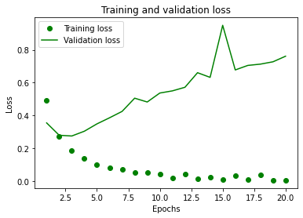

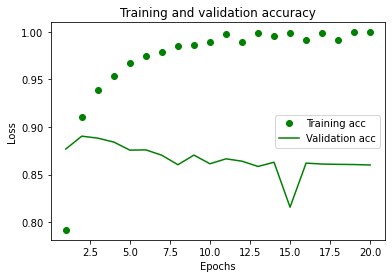

```python
import matplotlib.pyplot as plt

threely_accuracy = history.history['accuracy']
threely_val_accuracy = history.history['val_accuracy']
threely_loss = history.history['loss']
threely_val_loss = history.history['val_loss']

threely_epochs = range(1, len(threely_accuracy) + 1)

# "bo" is for "blue dot"
plt.plot(threely_epochs, threely_loss, 'go', label='Training loss')
# b is for "solid blue line"
plt.plot(threely_epochs, threely_val_loss, 'g', label='Validation loss')
plt.title('Training and validation loss')
plt.xlabel('Epochs')
plt.ylabel('Loss')
plt.legend()

plt.show()

plt.clf()   # clear figure
threely_acc_values = history_dict['accuracy']
threely_val_acc_values = history_dict['val_accuracy']

plt.plot(threely_epochs, threely_acc_values, 'go', label='Training acc')
plt.plot(threely_epochs, threely_val_acc_values, 'g', label='Validation acc')
plt.title('Training and validation accuracy')
plt.xlabel('Epochs')
plt.ylabel('Loss')
plt.legend()

plt.show()
```

```python
np.random.seed(123)
model = keras.Sequential([
    layers.Dense(16, activation="tanh"),
    layers.Dense(16, activation="tanh"),
    layers.Dense(16, activation="tanh"),
    layers.Dense(1, activation="sigmoid")
])

model.compile(optimizer='rmsprop',
              loss='binary_crossentropy',
              metrics=['accuracy'])

model.fit(x_train, y_train, epochs=2, batch_size=512)

results = model.evaluate(x_test, y_test)
```

```python
model.predict(x_test)
```

```
array([[0.21627593],
       [0.99405545],
       [0.97935647],
       ...,
       [0.1243034 ],
       [0.11981142],
       [0.6711564 ]], dtype=float32)
```

## Regularization

Feature engineering is the process of applying techniques such as regularization - Lasso or Ridge, dropout, early stopping, etc. to improve the performance of machine learning algorithms.

Regularization is the process of modulating the quantity of information a model is allowed to store or add. The most famous regularizers are Lasso (L2) and Ridge (L1).

**Dropout Regularization**

A Simple Way to Prevent Neural Networks from Overfitting, 2014. Because the outputs of a layer under dropout are randomly subsampled, it has the effect of reducing the capacity or thinning the network during training. As such, a wider network, e.g. more nodes, may be required when using dropout. Dropout regularization is a generic approach.

Like other regularization methods, dropout is more effective on those problems where there is a limited amount of training data and the model is likely to overfit the training data. how it works?

- **Deciding the hyper parameter :**

The default interpretation of the dropout hyperparameter is the probability of training a given node in a layer, where 1.0 means no dropout, and 0.0 means no outputs from the layer.

A good value for dropout in a hidden layer is between 0.5 and 0.8. Input layers use a larger dropout rate, such as of 0.8.

- **Process:**

The outputs of a layer under dropout are randomly subsampled, it has the effect of reducing the capacity or thinning the network during training. As such, a wider network, e.g. more nodes, may be required when using dropout. During training, some number of layer outputs are randomly ignored or “dropped out.” This has the effect of making the layer look-like and be treated-like a layer with a different number of nodes and connectivity to the prior layer. In effect, each update to a layer during training is performed with a different “view” of the configured layer.

Reference: https://machinelearningmastery.com/dropout-for-regularizing-deep-neural-networks/

**Model building using dropout technique**

```python
dpt_model = keras.Sequential([
    layers.Dense(16, activation="relu"),
    layers.Dropout(0.5),
    layers.Dense(16, activation="relu"),
    layers.Dropout(0.5),
    layers.Dense(16, activation="relu"),
    layers.Dropout(0.5),
    layers.Dense(1, activation="sigmoid")
])

dpt_model.compile(optimizer='rmsprop',
                  loss='binary_crossentropy',
                  metrics=['acc'])

# validation
x_val = x_train[:10000]
partial_x_train = x_train[10000:]

y_val = y_train[:10000]
partial_y_train = y_train[10000:]
```

```python
dpt_model_hist = dpt_model.fit(partial_x_train, partial_y_train,
                               epochs=20,
                               batch_size=512,
                               validation_data=(x_val, y_val))
```

```python
epochs = range(1, 21)
dpt_history_dict = dpt_model_hist.history
dpt_history_dict.keys()
```

```
dict_keys(['loss', 'acc', 'val_loss', 'val_acc'])
```

```python
### Original Model

from keras import models
from keras import layers

model = models.Sequential()
model.add(layers.Dense(16, activation='relu', input_shape=(10000,)))
model.add(layers.Dense(16, activation='relu'))
model.add(layers.Dense(16, activation='relu'))
model.add(layers.Dense(1, activation='sigmoid'))

model.compile(optimizer='rmsprop',
              loss='binary_crossentropy',
              metrics=['accuracy'])


original_hist = model.fit(x_train,
                    y_train,
                    epochs=20,
                    batch_size=512,
                    validation_data=(x_test, y_test))
```

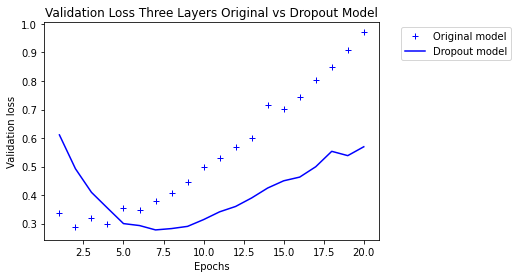

```python
import matplotlib.pyplot as plt

original_val_loss = original_hist.history['val_loss']
dpt_model_val_loss = dpt_model_hist.history['val_loss']

plt.plot(epochs, original_val_loss, 'b+', label='Original model')
plt.plot(epochs, dpt_model_val_loss, 'b', label='Dropout model')
plt.xlabel('Epochs')
plt.ylabel('Validation loss')
plt.legend(bbox_to_anchor=(1.05, 1.0), loc='upper left')
plt.title('Validation Loss Three Layers Original vs Dropout Model')
```

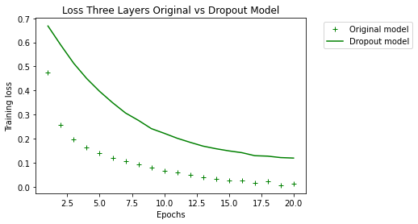

```python
original_loss = original_hist.history['loss']
dpt_model_loss = dpt_model_hist.history['loss']

plt.plot(epochs, original_loss, 'g+', label='Original model')
plt.plot(epochs, dpt_model_loss, 'g', label='Dropout model')
plt.xlabel('Epochs')
plt.ylabel('Training loss')
plt.legend(bbox_to_anchor=(1.05, 1.0), loc='upper left')
plt.title('Loss Three Layers Original vs Dropout Model')


plt.show()
```

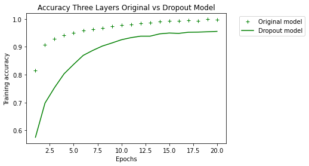

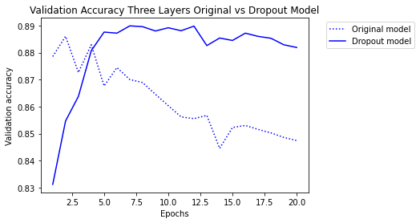

```python
original_accuracy = original_hist.history['accuracy']
dpt_model_accuracy = dpt_model_hist.history['acc']

plt.plot(epochs, original_accuracy, 'g+', label='Original model')
plt.plot(epochs, dpt_model_accuracy, 'g', label='Dropout model')
plt.xlabel('Epochs')
plt.ylabel('Training accuracy')
plt.legend(bbox_to_anchor=(1.05, 1.0), loc='upper left')
plt.title('Accuracy Three Layers Original vs Dropout Model')


plt.show()

original_val_accuracy = original_hist.history['val_accuracy']
dpt_model_val_accuracy = dpt_model_hist.history['val_acc']

plt.plot(epochs, original_val_accuracy, 'b:', label='Original model')
plt.plot(epochs, dpt_model_val_accuracy, 'b', label='Dropout model')
plt.xlabel('Epochs')
plt.ylabel('Validation accuracy')
plt.legend(bbox_to_anchor=(1.05, 1.0), loc='upper left')
plt.title('Validation Accuracy Three Layers Original vs Dropout Model')


plt.show()
```

## Summary

This section is about the summary of all techniques implemented to the model. At the end of this section, we will see a table summary showing the losses and accuracies of the models by changing the activation function, loss function, number of neurons, layers, and feature engineering techniques to find the best model.

### Building Neural Network with different layers

[figure not shown]

```python
from PIL import Image
myImage=Image.open("bar.jpg")
#myImage.show()
display(myImage)
```

**Observations:**

### Model with MSE instead of BinaryCrossEntropy

Firstly, Cross-entropy (or softmax loss, but cross-entropy works better) is a better measure than MSE for classification, because the decision boundary in a classification task is large (in comparison with regression). MSE doesn’t punish misclassifications enough but is the right loss for regression, where the distance between two values that can be predicted is small.

Here when i used these two fucntions, I dont find much difference in the both models but accuracy value is slighlt better in Binarycross entropy

### Model with tanh instead of relu

ReLu is the best and most advanced activation function right now compared to the sigmoid and TanH because all the drawbacks like Vanishing Gradient Problem is completely removed in this activation function which makes this activation function more advanced compare to other activation function.

When the both activations are applied and compared, it is seen that model performance using relu activation is good.

### Regularization using dropout technique

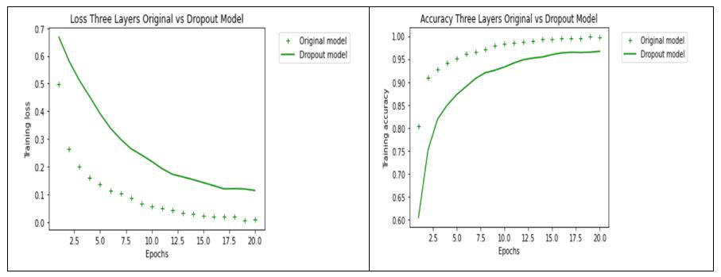

```python
from PIL import Image
myImage=Image.open("Regularisation_compare_loss.jpg")
#myImage.show()
display(myImage)
```

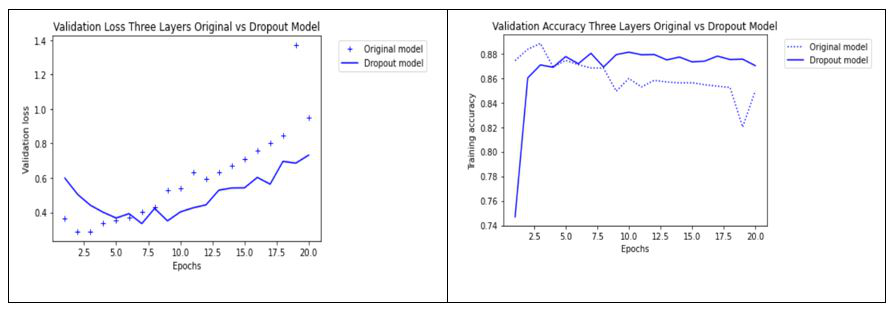

```python
from PIL import Image
myImage=Image.open("Regularisation_compare_accuracy.jpg")
#myImage.show()
display(myImage)
```

### Observations:

The above plots shows us the comparison between the loss and accuracy of the original model and regularised models with respect to traning and validation using drop out method.

- **Comparison with respect to training data:**

The original model( Neural Network with 3 layers and 16 neurons) is performing well than the drop out method model.

**Why the regularised model has some fluctuations to the original?**

That could be for several reasons:

### Conclusion

[figure not shown]

```python
from PIL import Image
myImage=Image.open("summary.jpg")
#myImage.show()
display(myImage)
```